# Intro_To_NN_Project

```python
from google.colab import drive
drive.mount('/content/gdrive')
```

```python
import pandas as pd
import numpy as np
import seaborn as sns
import matplotlib.pyplot as plt
%matplotlib inline
import pickle as pkl
%tensorflow_version 2.x
import tensorflow
from sklearn.model_selection import train_test_split
import random
random.seed(0)
import warnings
warnings.filterwarnings('ignore')
```

## **Project Part 1:**

**DOMAIN:** Electronics and Telecommunication

**CONTEXT:** A communications equipment manufacturing company has a product which is responsible for emitting informative signals. Company wants to build a machine learning model which can help the company to predict the equipment’s signal quality using various parameters.

**DATA DESCRIPTION:** The data set contains information on various signal tests performed:

1. Parameters: Various measurable signal parameters.
2. Signal_Quality: Final signal strength or quality

**PROJECT OBJECTIVE:** The need is to build a regressor which can use these parameters to determine the signal strength or quality [as number].

```python
signal = pd.read_csv('/content/gdrive/MyDrive/Project/Part- 1,2&3 - Signal.csv')
```

```python
signal.head()
```

|  | Parameter 1 | Parameter 2 | Parameter 3 | Parameter 4 | Parameter 5 | Parameter 6 | Parameter 7 | Parameter 8 | Parameter 9 | Parameter 10 | Parameter 11 | Signal_Strength |
| --- | --- | --- | --- | --- | --- | --- | --- | --- | --- | --- | --- | --- |
| 0 | 7.4 | 0.70 | 0.00 | 1.9 | 0.076 | 11.0 | 34.0 | 0.9978 | 3.51 | 0.56 | 9.4 | 5 |
| 1 | 7.8 | 0.88 | 0.00 | 2.6 | 0.098 | 25.0 | 67.0 | 0.9968 | 3.20 | 0.68 | 9.8 | 5 |
| 2 | 7.8 | 0.76 | 0.04 | 2.3 | 0.092 | 15.0 | 54.0 | 0.9970 | 3.26 | 0.65 | 9.8 | 5 |
| 3 | 11.2 | 0.28 | 0.56 | 1.9 | 0.075 | 17.0 | 60.0 | 0.9980 | 3.16 | 0.58 | 9.8 | 6 |
| 4 | 7.4 | 0.70 | 0.00 | 1.9 | 0.076 | 11.0 | 34.0 | 0.9978 | 3.51 | 0.56 | 9.4 | 5 |

```python
signal.shape
```

```
(1599, 12)
```

```python
signal.info()
```

```
<class 'pandas.core.frame.DataFrame'>
RangeIndex: 1599 entries, 0 to 1598
Data columns (total 12 columns):
 #   Column           Non-Null Count  Dtype
---  ------           --------------  -----
 0   Parameter 1      1599 non-null   float64
 1   Parameter 2      1599 non-null   float64
 2   Parameter 3      1599 non-null   float64
 3   Parameter 4      1599 non-null   float64
 4   Parameter 5      1599 non-null   float64
 5   Parameter 6      1599 non-null   float64
 6   Parameter 7      1599 non-null   float64
 7   Parameter 8      1599 non-null   float64
 8   Parameter 9      1599 non-null   float64
 9   Parameter 10     1599 non-null   float64
 10  Parameter 11     1599 non-null   float64
 11  Signal_Strength  1599 non-null   int64
dtypes: float64(11), int64(1)
memory usage: 150.0 KB
```

```python
signal.describe().transpose()
```

|  | count | mean | std | min | 25% | 50% | 75% | max |
| --- | --- | --- | --- | --- | --- | --- | --- | --- |
| Parameter 1 | 1599.0 | 8.319637 | 1.741096 | 4.60000 | 7.1000 | 7.90000 | 9.200000 | 15.90000 |
| Parameter 2 | 1599.0 | 0.527821 | 0.179060 | 0.12000 | 0.3900 | 0.52000 | 0.640000 | 1.58000 |
| Parameter 3 | 1599.0 | 0.270976 | 0.194801 | 0.00000 | 0.0900 | 0.26000 | 0.420000 | 1.00000 |
| Parameter 4 | 1599.0 | 2.538806 | 1.409928 | 0.90000 | 1.9000 | 2.20000 | 2.600000 | 15.50000 |
| Parameter 5 | 1599.0 | 0.087467 | 0.047065 | 0.01200 | 0.0700 | 0.07900 | 0.090000 | 0.61100 |
| Parameter 6 | 1599.0 | 15.874922 | 10.460157 | 1.00000 | 7.0000 | 14.00000 | 21.000000 | 72.00000 |
| Parameter 7 | 1599.0 | 46.467792 | 32.895324 | 6.00000 | 22.0000 | 38.00000 | 62.000000 | 289.00000 |
| Parameter 8 | 1599.0 | 0.996747 | 0.001887 | 0.99007 | 0.9956 | 0.99675 | 0.997835 | 1.00369 |
| Parameter 9 | 1599.0 | 3.311113 | 0.154386 | 2.74000 | 3.2100 | 3.31000 | 3.400000 | 4.01000 |
| Parameter 10 | 1599.0 | 0.658149 | 0.169507 | 0.33000 | 0.5500 | 0.62000 | 0.730000 | 2.00000 |
| Parameter 11 | 1599.0 | 10.422983 | 1.065668 | 8.40000 | 9.5000 | 10.20000 | 11.100000 | 14.90000 |
| Signal_Strength | 1599.0 | 5.636023 | 0.807569 | 3.00000 | 5.0000 | 6.00000 | 6.000000 | 8.00000 |

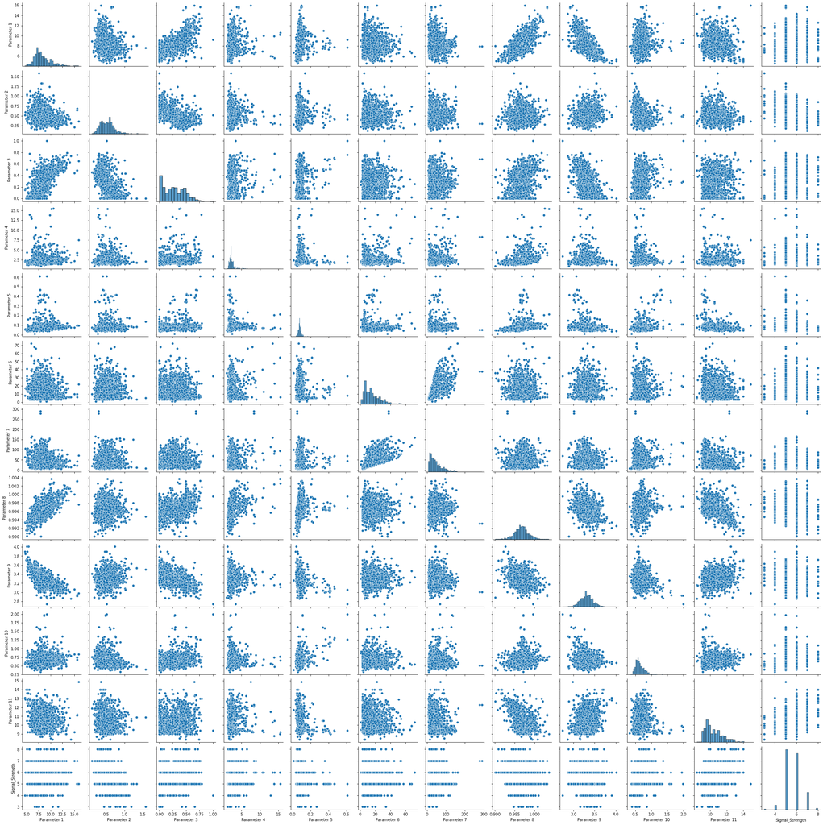

```python
sns.pairplot(signal);
```

```python
signal.corr()
```

|  | Parameter 1 | Parameter 2 | Parameter 3 | Parameter 4 | Parameter 5 | Parameter 6 | Parameter 7 | Parameter 8 | Parameter 9 | Parameter 10 | Parameter 11 | Signal_Strength |
| --- | --- | --- | --- | --- | --- | --- | --- | --- | --- | --- | --- | --- |
| Parameter 1 | 1.000000 | -0.256131 | 0.671703 | 0.114777 | 0.093705 | -0.153794 | -0.113181 | 0.668047 | -0.682978 | 0.183006 | -0.061668 | 0.124052 |
| Parameter 2 | -0.256131 | 1.000000 | -0.552496 | 0.001918 | 0.061298 | -0.010504 | 0.076470 | 0.022026 | 0.234937 | -0.260987 | -0.202288 | -0.390558 |
| Parameter 3 | 0.671703 | -0.552496 | 1.000000 | 0.143577 | 0.203823 | -0.060978 | 0.035533 | 0.364947 | -0.541904 | 0.312770 | 0.109903 | 0.226373 |
| Parameter 4 | 0.114777 | 0.001918 | 0.143577 | 1.000000 | 0.055610 | 0.187049 | 0.203028 | 0.355283 | -0.085652 | 0.005527 | 0.042075 | 0.013732 |
| Parameter 5 | 0.093705 | 0.061298 | 0.203823 | 0.055610 | 1.000000 | 0.005562 | 0.047400 | 0.200632 | -0.265026 | 0.371260 | -0.221141 | -0.128907 |
| Parameter 6 | -0.153794 | -0.010504 | -0.060978 | 0.187049 | 0.005562 | 1.000000 | 0.667666 | -0.021946 | 0.070377 | 0.051658 | -0.069408 | -0.050656 |
| Parameter 7 | -0.113181 | 0.076470 | 0.035533 | 0.203028 | 0.047400 | 0.667666 | 1.000000 | 0.071269 | -0.066495 | 0.042947 | -0.205654 | -0.185100 |
| Parameter 8 | 0.668047 | 0.022026 | 0.364947 | 0.355283 | 0.200632 | -0.021946 | 0.071269 | 1.000000 | -0.341699 | 0.148506 | -0.496180 | -0.174919 |
| Parameter 9 | -0.682978 | 0.234937 | -0.541904 | -0.085652 | -0.265026 | 0.070377 | -0.066495 | -0.341699 | 1.000000 | -0.196648 | 0.205633 | -0.057731 |
| Parameter 10 | 0.183006 | -0.260987 | 0.312770 | 0.005527 | 0.371260 | 0.051658 | 0.042947 | 0.148506 | -0.196648 | 1.000000 | 0.093595 | 0.251397 |
| Parameter 11 | -0.061668 | -0.202288 | 0.109903 | 0.042075 | -0.221141 | -0.069408 | -0.205654 | -0.496180 | 0.205633 | 0.093595 | 1.000000 | 0.476166 |
| Signal_Strength | 0.124052 | -0.390558 | 0.226373 | 0.013732 | -0.128907 | -0.050656 | -0.185100 | -0.174919 | -0.057731 | 0.251397 | 0.476166 | 1.000000 |

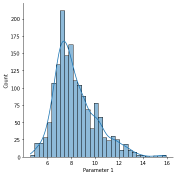

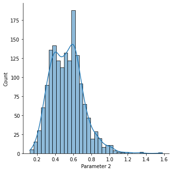

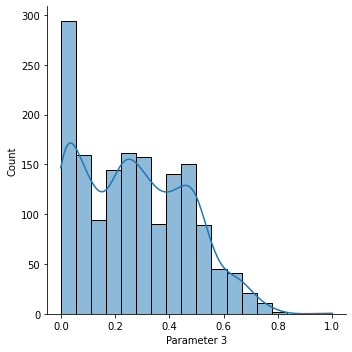

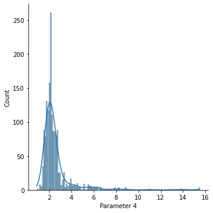

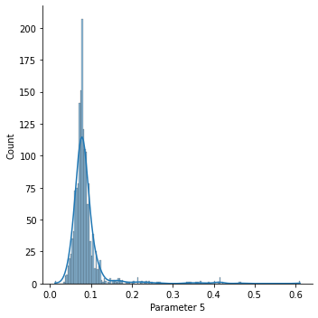

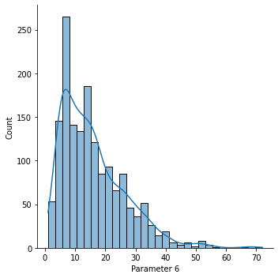

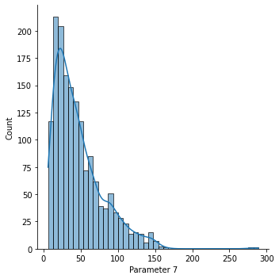

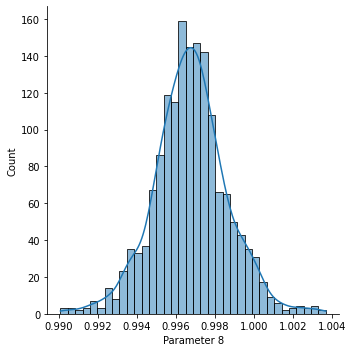

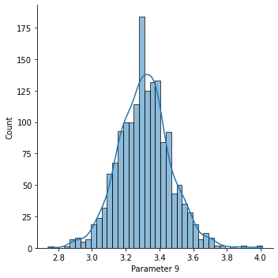

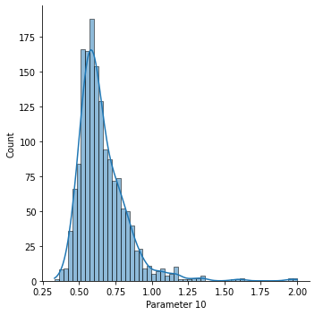

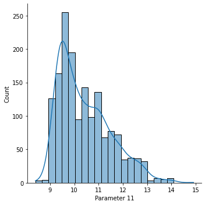

```python
x = signal.drop('Signal_Strength', axis=1)
for parameters in x:
  sns.displot(data=signal, x=parameters, kde= True)
```

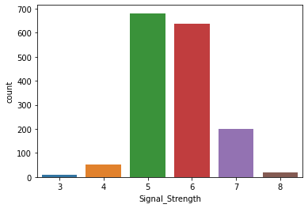

```python
y = signal['Signal_Strength']

sns.countplot(y)
```

```python
display(x.shape, y.shape)
```

```
(1599, 11)
```

```
(1599,)
```

```python
corr_with_signal_strength=[]
indep_cols = signal.drop('Signal_Strength', axis = 1).columns

for cols in indep_cols:
    corr_with_signal_strength.append(signal['Signal_Strength'].corr(signal[cols]))

display(pd.DataFrame([indep_cols, corr_with_signal_strength], index = ['Independent Column', 'Corr with Signal Strength']).transpose())
```

|  | Independent Column | Corr with Signal Strength |
| --- | --- | --- |
| 0 | Parameter 1 | 0.124052 |
| 1 | Parameter 2 | -0.390558 |
| 2 | Parameter 3 | 0.226373 |
| 3 | Parameter 4 | 0.0137316 |
| 4 | Parameter 5 | -0.128907 |
| 5 | Parameter 6 | -0.0506561 |
| 6 | Parameter 7 | -0.1851 |
| 7 | Parameter 8 | -0.174919 |
| 8 | Parameter 9 | -0.0577314 |
| 9 | Parameter 10 | 0.251397 |
| 10 | Parameter 11 | 0.476166 |

From the above table we can notice that, Parameter 4,6 and 9 have close to no correlation with signal strength. We will drop these column and check the loss function.

```python
x_new = signal.drop(['Parameter 4', 'Parameter 6', 'Parameter 9'], axis = 1)
y_new =signal['Signal_Strength']
```

```python
x_train,x_test,y_train,y_test = train_test_split(x_new,y_new,test_size = 0.2, random_state = 1)
```

```
Train: 0.231, Test: 0.225
```

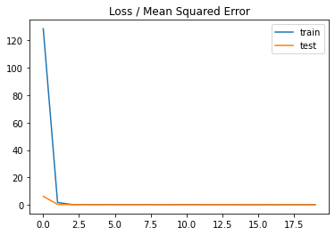

```python
from keras.models import Sequential
from keras.layers import Dense
from keras.optimizers import SGD
from matplotlib import pyplot

# define model1
model1 = Sequential()
model1.add(Dense(25, input_dim=9, activation='relu', kernel_initializer='he_uniform'))
model1.add(Dense(1, activation='linear'))
opt = SGD(lr=0.00001, momentum=0.93)
model1.compile(loss='mean_squared_error', optimizer=opt)
# fit model
history = model1.fit(x_train, y_train, validation_data=(x_test, y_test), epochs=20, verbose=1, batch_size =25)
# evaluate the model
train_mse = model1.evaluate(x_train, y_train, verbose=0)
test_mse = model1.evaluate(x_test, y_test, verbose=0)
print('Train: %.3f, Test: %.3f' % (train_mse, test_mse))
# plot loss during training
pyplot.title('Loss / Mean Squared Error')
pyplot.plot(history.history['loss'], label='train')
pyplot.plot(history.history['val_loss'], label='test')
pyplot.legend()
pyplot.show()
```

```
Train: 0.034, Test: 0.034
```

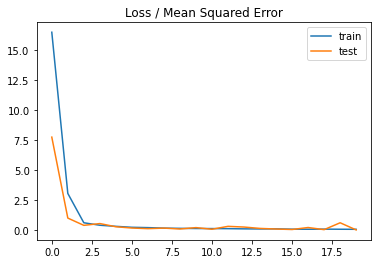

```python
# define model2
model2 = Sequential()
model2.add(Dense(25, input_dim=9, activation='relu', kernel_initializer='he_uniform'))
model2.add(Dense(1, activation='linear'))
model2.compile(loss='mean_squared_error', optimizer='rmsprop')
# fit model
history = model2.fit(x_train, y_train, validation_data=(x_test, y_test), epochs=20, verbose=1, batch_size =25)
# evaluate the model
train_mse = model2.evaluate(x_train, y_train, verbose=0)
test_mse = model2.evaluate(x_test, y_test, verbose=0)
print('Train: %.3f, Test: %.3f' % (train_mse, test_mse))
# plot loss during training
pyplot.title('Loss / Mean Squared Error')
pyplot.plot(history.history['loss'], label='train')
pyplot.plot(history.history['val_loss'], label='test')
pyplot.legend()
pyplot.show()
```

```
Train: 0.028, Test: 0.029
```

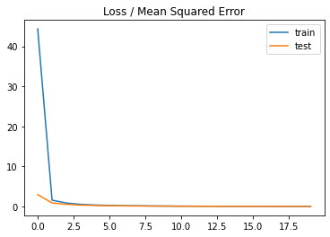

```python
from keras.optimizers import Adam
# define model3
model3 = Sequential()
model3.add(Dense(25, input_dim=9, activation='relu', kernel_initializer='he_uniform'))
model3.add(Dense(1, activation='linear'))
opt = Adam(learning_rate=0.01)
model3.compile(loss='mean_squared_error', optimizer= opt)
# fit model
history = model3.fit(x_train, y_train, validation_data=(x_test, y_test), epochs=20, verbose=1, batch_size =25)
# evaluate the model
train_mse = model3.evaluate(x_train, y_train, verbose=0)
test_mse = model3.evaluate(x_test, y_test, verbose=0)
print('Train: %.3f, Test: %.3f' % (train_mse, test_mse))
# plot loss during training
pyplot.title('Loss / Mean Squared Error')
pyplot.plot(history.history['loss'], label='train')
pyplot.plot(history.history['val_loss'], label='test')
pyplot.legend()
pyplot.show()
```

```python
from keras.models import model_from_yaml
```

```python
signal_strength = model3.to_yaml()
```

### Project 1 : Conclusion

The aim of the is to build a regressor which can use the parameters to determine the signal strength.

We first imported the provided file and then performed analysis on it. We saw the file has 1599 rows and 12 columns. We checked for any null values. There were no null values.

We checked the correlation of each parameter with the signal_strength column. We dropped 'Parameter 4', 'Parameter 6', 'Parameter 9' because the correlation with the target column was very less.

We split the set into training and testing set in the ration 80:20.

We built three deep learning model, to predict the signal strength from the remaining parameters.

1. Model 1: We used the Stochastic Gradient Descent optimizer. For which, the loss on Train: 0.231, Test: 0.225.
2. Model 2: We used the RMSPROP optimizer. For which, the loss on Train: 0.034, Test: 0.034.
3. Model 3: We used the Adam optimizer. For which, the loss on Train: 0.028, Test: 0.029

## **Project Part 2**

**DOMAIN:** Autonomous Vehicles

**BUSINESS CONTEXT:** A Recognising multi-digit numbers in photographs captured at street level is an important component of modern-day map making. A classic example of a corpus of such street-level photographs is Google’s Street View imagery composed of hundreds of millions of geo-located 360-degree panoramic images. The ability to automatically transcribe an address number from a geo-located patch of pixels and associate the transcribed number with a known street address helps pinpoint, with a high degree of accuracy, the location of the building it represents. More broadly, recognising numbers in photographs is a problem of interest to the optical character recognition community. While OCR on constrained domains like document processing is well studied, arbitrary multi-character text recognition in photographs is still highly challenging. This difficulty arises due to the wide variability in the visual appearance of text in the wild on account of a large range of fonts, colours, styles, orientations, and character arrangements. The recognition problem is further complicated by environmental factors such as lighting, shadows, specularity, and occlusions as well as by image acquisition factors such as resolution, motion, and focus blurs. In this project, we will use the dataset with images centred around a single digit (many of the images do contain some distractors at the sides). Although we are taking a sample of the data which is simpler, it is more complex than MNIST because of the distractors.

**DATA DESCRIPTION:** The SVHN is a real-world image dataset for developing machine learning and object recognition algorithms with the minimal requirement on data formatting but comes from a significantly harder, unsolved, real-world problem (recognising digits and numbers in natural scene images). SVHN is obtained from house numbers in Google Street View images. Where the labels for each of this image are the prominent number in that image i.e. 2,6,7 and 4 respectively.The dataset has been provided in the form of h5py files.

**PROJECT OBJECTIVE:** We will build a digit classifier on the SVHN (Street View Housing Number) dataset.

```python
import h5py
from tensorflow.keras.models import Sequential
from tensorflow.keras.layers import Dense, Flatten, Conv2D
from tensorflow.keras.losses import sparse_categorical_crossentropy
from tensorflow.keras.optimizers import Adam
```

```python
auto = h5py.File('/content/gdrive/MyDrive/Project/Part - 4 - Autonomous_Vehicles_SVHN_single_grey1.h5', 'r')
```

```python
auto.keys()
```

```
<KeysViewHDF5 ['X_test', 'X_train', 'X_val', 'y_test', 'y_train', 'y_val']>
```

```python
x_test = auto.get('X_test')
x_test
```

```
<HDF5 dataset "X_test": shape (18000, 32, 32), type "<f4">
```

```python
x_train = auto.get('X_train')
x_train
```

```
<HDF5 dataset "X_train": shape (42000, 32, 32), type "<f4">
```

```python
x_val = auto.get('X_val')
x_val
```

```
<HDF5 dataset "X_val": shape (60000, 32, 32), type "<f4">
```

```python
y_test = auto.get('y_test')
y_test
```

```
<HDF5 dataset "y_test": shape (18000,), type "|u1">
```

```python
y_train = auto.get('y_train')
y_train
```

```
<HDF5 dataset "y_train": shape (42000,), type "|u1">
```

```python
y_val = auto.get('y_val')
y_val
```

```
<HDF5 dataset "y_val": shape (60000,), type "|u1">
```

```python
input_train = np.array(auto['X_train'])
label_train = np.array(auto['y_train'])
input_val = np.array(auto['X_val'])
label_val = np.array(auto['y_val'])
input_test = np.array(auto['X_test'])
label_test = np.array(auto['y_test'])
```

```
Label: 6
```

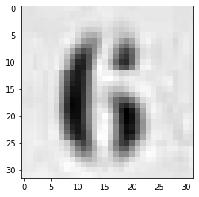

```python
import matplotlib.pyplot as plt
%matplotlib inline
print("Label: {}".format(label_train[1000]))
plt.imshow(input_train[1000], cmap='gray')
```

```python
print(input_train.shape)
print(label_train.shape)
print(input_val.shape)
print(label_val.shape)
print(input_test.shape)
print(label_test.shape)
```

```
(42000, 32, 32)
(42000,)
(60000, 32, 32)
(60000,)
(18000, 32, 32)
(18000,)
```

## Reshape Features:

- reshape() method gives a new shape to an array without changing its data.

```python
input_train = input_train.reshape(42000, 1024)
print(input_train.shape)
input_val = input_val.reshape(60000, 1024)
print(input_val.shape)
input_test = input_test.reshape(18000, 1024)
print(input_test.shape)
```

```
(42000, 1024)
(60000, 1024)
(18000, 1024)
```

```python
print(input_train.max())
print(input_train.min())
print(input_val.max())
print(input_val.min())
print(input_test.max())
print(input_test.min())
```

```
254.9745
0.0
254.9745
0.0
254.9745
0.0
```

```python
input_train = input_train/254.9745
input_val = input_val/254.9745
input_test = input_test/254.9745
```

```python
print(input_train.max())
print(input_train.min())
print(input_val.max())
print(input_val.min())
print(input_test.max())
print(input_test.min())
```

```
1.0
0.0
1.0
0.0
1.0
0.0
```

```python
print(label_train[10])
label_train = tensorflow.keras.utils.to_categorical(label_train, num_classes=10)
label_val = tensorflow.keras.utils.to_categorical(label_val, num_classes=10)
label_test = tensorflow.keras.utils.to_categorical(label_test, num_classes=10)
print(label_train[10])
```

```
1
[0. 1. 0. 0. 0. 0. 0. 0. 0. 0.]
```

```
label for each of the below image: 2
label for each of the below image: 6
label for each of the below image: 7
label for each of the below image: 4
label for each of the below image: 4
label for each of the below image: 0
label for each of the below image: 3
label for each of the below image: 0
label for each of the below image: 7
label for each of the below image: 3
```

```python
# visualizing the first 10 images in the dataset and their labels
%matplotlib inline
import matplotlib.pyplot as plt
plt.figure(figsize=(10, 1))
for i in range(10):
    plt.subplot(1, 10, i+1)
    plt.imshow(input_train[i].reshape(32, 32), cmap="gray")
    plt.axis('off')
    print('label for each of the below image: %s' % (np.argmax(label_train[0:10][i])))
plt.show()
```

[output not shown]

```python
from tensorflow.keras.models import Sequential
from tensorflow.keras.layers import Dense
from tensorflow.keras import regularizers, optimizers

def train_and_test_loop(iterations, lr, Lambda, verb=True):

    ## hyperparameters
    iterations = iterations
    learning_rate = lr
    hidden_nodes = 256
    output_nodes = 10

    model = Sequential()
    model.add(Dense(hidden_nodes, input_shape=(1024,), activation='relu'))
    model.add(Dense(hidden_nodes, activation='relu'))
    model.add(Dense(output_nodes, activation='softmax', kernel_regularizer=regularizers.l2(Lambda)))

    sgd = optimizers.SGD(lr=learning_rate, decay=1e-6, momentum=0.9)
    # Compile model
    model.compile(loss='categorical_crossentropy', optimizer=sgd, metrics=['accuracy'])

    # Fit the model
    model.fit(input_train, label_train, epochs=iterations, batch_size=1000, verbose= 1)
```

```python
def train_and_test_loop1(iterations, lr, Lambda, verb=True):

    ## hyperparameters
    iterations = iterations
    learning_rate = lr
    hidden_nodes = 256
    output_nodes = 10

    model = Sequential()
    model.add(Dense(hidden_nodes, input_shape=(1024,), activation='relu'))
    model.add(Dense(hidden_nodes, activation='relu'))
    model.add(Dense(output_nodes, activation='softmax', kernel_regularizer=regularizers.l2(Lambda)))

    sgd = optimizers.SGD(lr=learning_rate, decay=1e-6, momentum=0.9)
    # Compile model
    model.compile(loss='categorical_crossentropy', optimizer=sgd, metrics=['accuracy'])

    # Fit the model
    history = model.fit(input_train, label_train, epochs=iterations, batch_size=1000, verbose= 1, validation_data = (input_val, label_val))
    score = model.evaluate(input_train, label_train, verbose=0)

    # plot loss
    pyplot.title('Loss')
    pyplot.plot(history.history['loss'], label='train')
    pyplot.plot(history.history['val_loss'], label='val')
    pyplot.legend()
    pyplot.show()

    # plot accuracy
    pyplot.title('Accuracy')
    pyplot.plot(history.history['accuracy'], label='train')
    pyplot.plot(history.history['val_accuracy'], label='val')
    pyplot.legend()
    pyplot.show()

    return score
```

```python
lr = 0.00001
Lambda = 0
train_and_test_loop(1, lr, Lambda)
```

[output not shown]

**Now, lets increase the Lambda(Regularization)and see what it does to our loss function.**

```python
lr = 0.00001
Lambda = 1e3
train_and_test_loop(1, lr, Lambda)
```

[output not shown]

**Lets overfit to a small subset of our dataset, in this case 25 images, to ensure our model architecture is good**

```python
input_train_subset = input_train[0:25]
label_train_subset = label_train[0:25]
```

```python
input_train = input_train_subset
label_train = label_train_subset
```

```python
input_train.shape
```

```
(25, 1024)
```

```python
label_train.shape
```

```
(25, 10)
```

```python
lr = 0.001
Lambda = 0
train_and_test_loop(500, lr, Lambda)
```

[output not shown]

### **Loading original Dataset Again.**

```python
data = h5py.File('/content/gdrive/MyDrive/Project/Part - 4 - Autonomous_Vehicles_SVHN_single_grey1.h5', 'r')
```

```python
input_train = np.array(data['X_train'])
label_train = np.array(data['y_train'])
input_val = np.array(data['X_val'])
label_val = np.array(data['y_val'])
input_test = np.array(data['X_test'])
label_test = np.array(data['y_test'])
```

```python
input_train = input_train.reshape(42000, 1024)
print(input_train.shape)
input_val = input_val.reshape(60000, 1024)
print(input_val.shape)
input_test = input_test.reshape(18000, 1024)
print(input_test.shape)
```

```
(42000, 1024)
(60000, 1024)
(18000, 1024)
```

```python
input_train = input_train/254.9745
input_val = input_val/254.9745
input_test = input_test/254.9745
```

```python
label_train = tensorflow.keras.utils.to_categorical(label_train, num_classes=10)
label_val = tensorflow.keras.utils.to_categorical(label_val, num_classes=10)
label_test = tensorflow.keras.utils.to_categorical(label_test, num_classes=10)
```

### Start with small regularization and find learning rate that makes the loss go down.

- we start with Lambda(small regularization) = 1e-7
- we start with a small learning rate = 1e-7

```python
lr = 1e-7
Lambda = 1e-7
train_and_test_loop(20, lr, Lambda)
```

[output not shown]

- Learning rate lr = 1e8
- Regularization lambda = 1e-7

```python
lr = 1e8
Lambda = 1e-7
train_and_test_loop(20, lr, Lambda)
```

[output not shown]

### Lets try to train now with a value of learning rate between 1e-7 and 1e8

- learning rate = 1e4
- regularization remains the small, lambda = 1e-7

```python
lr = 1e4
Lambda = 1e-7
train_and_test_loop(20, lr, Lambda)
```

[output not shown]

### Running deep with lr=0.02 and Lambda=1e-4

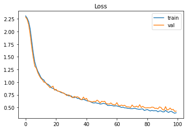

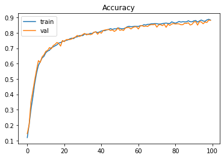

```
[0.3675156235694885, 0.8963809609413147]
```

```python
lr = 2e-2
Lambda = 1e-4
train_and_test_loop1(100, lr, Lambda)
```

```python
def train_and_test_loop2(iterations, lr, Lambda, verb=True):

    ## hyperparameters
    iterations = iterations
    learning_rate = lr
    hidden_nodes = 512
    output_nodes = 10

    model = Sequential()
    model.add(Dense(hidden_nodes, input_shape=(1024,), activation='relu'))
    model.add(Dense(hidden_nodes, activation='relu'))
    model.add(Dense(output_nodes, activation='softmax', kernel_regularizer=regularizers.l2(Lambda)))

    adam = optimizers.Adam(lr=learning_rate, epsilon = 1e-8, beta_1 = 0.9, beta_2 = 0.999)
    # Compile model
    model.compile(loss='categorical_crossentropy', optimizer=adam, metrics=['accuracy'])

    # Fit the model
    history = model.fit(input_train, label_train, epochs=iterations, batch_size=1000, verbose= 1, validation_data=(input_val,label_val))
    score = model.evaluate(input_train, label_train, verbose=0)

    # plot loss
    pyplot.title('Loss')
    pyplot.plot(history.history['loss'], label='train')
    pyplot.plot(history.history['val_loss'], label='val')
    pyplot.legend()
    pyplot.show()

    # plot accuracy
    pyplot.title('Accuracy')
    pyplot.plot(history.history['accuracy'], label='train')
    pyplot.plot(history.history['val_accuracy'], label='val')
    pyplot.legend()
    pyplot.show()

    return score
```

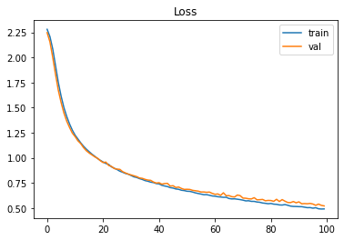

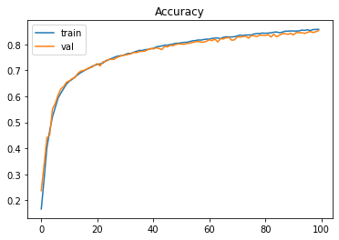

```
[0.4766865670681, 0.864380955696106]
```

```python
lr = 0.0001
Lambda = 0
train_and_test_loop2(100, lr, Lambda)
```

### Project 2 : Conculsion

**In this view, we can conclude that with SGD as the optimizer we can the image classification will give a better accuracy i.e. 89% at a loss of 0.37.**